# Melbourne Housing Market - Paper2

# 5 k-NN

We used a k-nearest neighbors model to build a classifier to predict housing price category (`Price.cuts`). K-nearest neighbors is a supervised classification machine learning algorithm for a categorical response variable. After exploring different numbers and combinations of variables, our final model used seven variables: `Car`, `Distance`, `Rooms`, `Region`, `Latitude`, `Longitude`, and `Property Count`. Next, we determined the optimal k value. We ran the model with k values ranging from 3 to 13 and found that 13 produced the highest accuracy.

## 5.1 Accuracy of k-NN

Total Accuracy Summary

| k | Total.Accuracy |
| --- | --- |
| 13 | 0.734 |

Thus, our model is a 13-nn and it predicted housing price category with a little over 73% accuracy.

## 5.2 ROC for k-NN

Area under the curve: 0.766

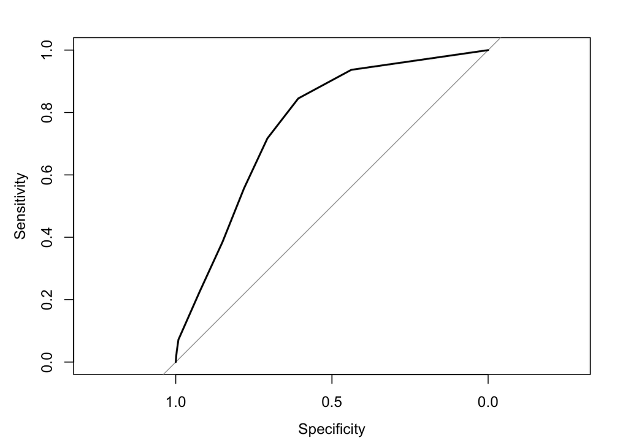

Next, we did an ROC-AUC to examine the quality of our classifier and found that it had an AUC score of 0.76. This a bit below the 0.8 threshold that one would typically like to see. A good classifier achieves an AUC score of 0.8 or above, so we can conclude our model produced a decent, but not great, classifier of housing price.

# 6 Final Results

## 6.1 Results for Regression Models

| Method | R^2 | MSE |
| --- | --- | --- |
| BIC Selection | 0.45 | 2.40e+11 |
| Lasso | 0.47 | 2.31e+11 |
| Lasso: Normalized | 0.47 | 2.31e+11 |
| Random Forest | 0.81 | 8.313e+10 |

## 6.2 Accuracy for Classifiers

Project one does not consider classification models; so, no comparisons will be attempted between the projects. Here, we can see that when only considering overall accuracy, the random forest again outperformed the other attempted models.

| Method | Accuracy |
| --- | --- |
| Tree | 0.704 |
| Random Forest | 0.831 |
| 13-NN | 0.734 |

# 7 Conclusion

By using these different modelling techniques, we have seen an improvement in our results compared to the linear regression model we built in project 1. Our classification models performed much better than our continuous methods overall. However, random forest outperformed all the other models in terms of accuracy. This aligns with previous research comparing modelling techniques for housing price prediction. The random forest classifier was the best out of the random forest methods we tried. We conclude that the random forest is the best modelling technique for predicting housing price using the Melbourne Housing Snapshot dataset.

# 8 Bibliography

Deng, Houtao & Runger, George & Tuv, Eugene. (2011). Bias of Importance Measures for Multi-valued Attributes and Solutions. Lecture Notes in Computer Science. 6792. 293-300. 10.1007/978-3-642-21738-8_38.

Mohd, T., Jamil, N. S., Johari, N., Abdullah, L., & Masrom, S. (2020). An overview of real estate modelling techniques for house price prediction. Charting a Sustainable Future of ASEAN in Business and Social Sciences, 321-338. doi:10.1007/978-981-15-3859-9_28

Tibshirani, R. (1996). Regression shrinkage and selection via the lasso. Journal of the Royal Statistical Society: Series B (Methodological), 58(1), 267-288.